# Wenatchee 2015 Max

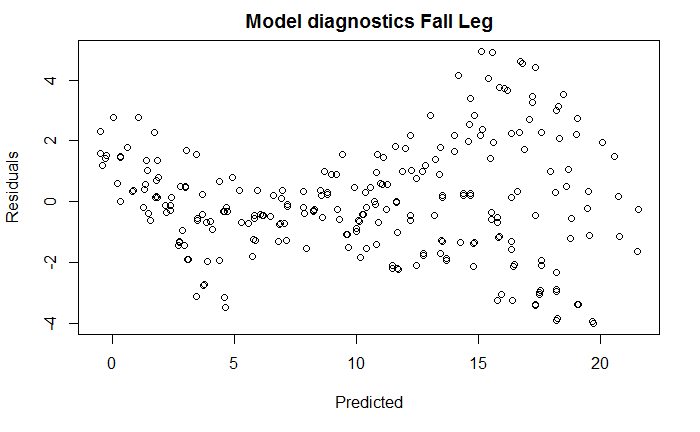

```r
  plot(pred.y, mod$residuals, main="Model diagnostics Fall Leg", xlab="Predicted", ylab="Residuals")
```

format data for prediction output

```r
  coeffs <- as.matrix(coefficients(mod))
  post_mod <- summary(lm(y ~ pred.y))
```

LOO PRESS stats

```r
  pressstat_sum <- PRESS(sum_mod, verbose = "FALSE")
  RMSEP <- sqrt(mean((pressstat_sum$residuals)^2))

  library(pls)
  mod2 <- plsr(y ~ x + I(x^2) + z + e, validation = "LOO")
  p2 <- R2(mod2)
  detach("package:pls", unload=TRUE)
```

write out predicted, coeffs, & metrics

```r
  pred.out <- matrix(nrow=length(pred.y), ncol=5)
  pred.out[,1] <- y
  pred.out[,2] <- pred.y
  pred.out[,3] <- z
  pred.out[,4] <- "fall"
  pred.out[,5] <- yearPath

  write.table (x=pred.out,append=T,row.names=F,file=paste0("jk_pred_v_y_", var, "_", basin, "_", yearPath, "_sp_fall.csv"),sep = ",", col.names=F)

  coeffs_out[2,1] <- coeffs[1,1]
  coeffs_out[2,2] <- coeffs[2,1]
  coeffs_out[2,3] <- coeffs[3,1]
  coeffs_out[2,4] <- coeffs[4,1]
  coeffs_out[2,5] <- coeffs[5,1]

  metrics_out[2,1] <- sum_mod$adj.r.squared
  metrics_out[2,2] <- post_mod$sigma
  metrics_out[2,3] <- p2$val[5]
  metrics_out[2,4] <- RMSEP
  metrics_out[2,5] <- length(unique(data.fall$SiteName))
  metrics_out[2,6] <- length(y)
```

Write out tables

```r
  write.table(x=coeffs_out, append=F,row.names=T, file = paste0("All_data_", basin, "_", yearPath, "_mod_coeffs_", var, ".csv"), sep = ",", col.names=T)

  write.table(x=metrics_out, append=F,row.names=T, file = paste0("All_data_", basin, "_", yearPath, "_mod_metrics_", var, ".csv"), sep = ",", col.names=T)

  write.table(x=metrics_out, append=F,row.names=T, file = paste0(metricPath, yearPath, "_temp_CHaMP/model_metrics/","All_data_", basin, "_", yearPath, "_mod_metrics_", var, ".csv"), sep = ",", col.names=NA)
```

plot the full year of predicted v observed

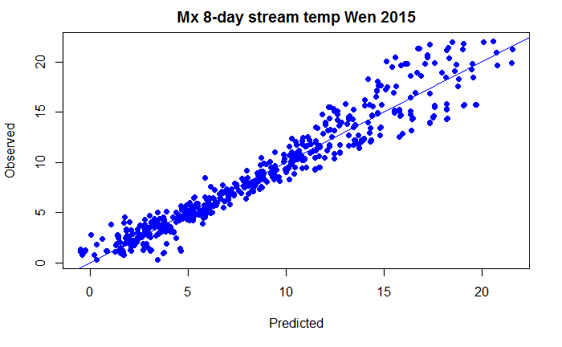

```r
  pred.y <- read.csv(paste0("jk_pred_v_y_", var, "_", basin, "_", yearPath, "_sp_fall.csv"), stringsAsFactors = FALSE, header = FALSE)
  colnames(pred.y) <- c("Y", "PredY", "JulDay", "Season", "Year")

  {plot(pred.y$PredY, pred.y$Y, pch=16, col="blue", main=paste0(var, " 8-day stream temp ", basin, " ", yearPath), xlab="Predicted", ylab="Observed")
  abline(0,1)
  abline(lm(pred.y$Y~ pred.y$PredY), col="blue")}
```

full year fit metrics

```r
  fit <- lm(pred.y$Y~ pred.y$PredY)

  summary(fit)
```

```
Call:
lm(formula = pred.y$Y ~ pred.y$PredY)

Residuals:
    Min      1Q  Median      3Q     Max
-4.0021 -0.6885 -0.1151  0.5769  4.9536

Coefficients:
              Estimate Std. Error t value Pr(>|t|)
(Intercept)  -0.003732   0.102762  -0.036    0.971
pred.y$PredY  1.000353   0.010699  93.503   <2e-16 ***
---
Signif. codes:  0 ‘***’ 0.001 ‘**’ 0.01 ‘*’ 0.05 ‘.’ 0.1 ‘ ’ 1

Residual standard error: 1.36 on 600 degrees of freedom
Multiple R-squared:  0.9358,    Adjusted R-squared:  0.9357
F-statistic:  8743 on 1 and 600 DF,  p-value: < 2.2e-16
```

Plot some reaches to take a peek

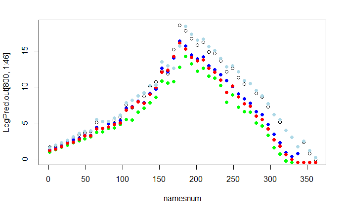

```r
  {plot(namesnum, LogPred.out[800,1:46])
  points(namesnum, LogPred.out[10, 1:46], pch=16, col="blue")
  points(namesnum, LogPred.out[1000, 1:46], pch=16, col="green")
  points(namesnum, LogPred.out[1, 1:46], pch=16, col="red")
  points(namesnum, LogPred.out[100, 1:46], pch=16, col="lightblue")}
```

```r
NA
```

Geospatial data output

```r
  network <- readOGR(dsn=gisPath, layer = netname)
```

[output not shown]

Animation output

```r
    rca <- readOGR(dsn=gisPath, layer = rcaName)
    rca <- readOGR(dsn=gisPath, layer = rcaName)
    rcas <- rca@data
    rcas$STHD_IP <- as.character(rcas$STHD_IP)
    rcas$STHD_IP <- as.character(rcas$STHD_IP)
    rcas$CHNK_IP <- as.character(rcas$CHNK_IP)
    ext <- "STHD"
```

loops through and writes out the graphics

```r
  for (i in 3:48)
    {

      namey <- gsub(paste0("T", var, "_", yrPath, "_"), "", colnames(net@data)[i])

      filename <- paste0(modelPath, "/graphics/", namer[i-2], ".png", sep="")
      png(filename=filename, res = 300, width = 1500, height = 1500, units = "px", bg="black")

      fix3 <- classIntervals(net@data[,i], n = 11, style = "fixed",fixedBreaks=c(-1,2,4,6,8,10,12,14,16,18, 20))
      fix3.colors <- findColours(fix3,pal=seis)

      cexEr <-ifelse(abs(error_pts@data[,i]) == 0, 0,
                     ifelse(abs(error_pts@data[,i])>0 & error_pts@data[,i-1]<1, 0.5,
                            ifelse(abs(error_pts@data[,i])>1 & error_pts@data[,i-1]<2, 0.75,
                                   ifelse(abs(error_pts@data[,i])>2 & error_pts@data[,i]<3, 1.0,
                                          ifelse(abs(error_pts@data[,i])>3, 1.25,
                                                 ifelse(abs(error_pts@data[,i])== NA, 0, NA))))))

      plot(net, col=fix3.colors, bg="black", fg="white")
      points(error_pts, pch=16, col="gray40", cex=cexEr)

       legend("right", fill = attr(fix3.colors, "palette"), title=paste0("8-day ", longVar, " (°C)"),legend = c("0-6","6-8","8-10","10-12","12-14","14-16","16-18","18-20", "20-22", "22+"), bty = "n", cex=.5, inset=c(0,0), text.col="white");
        legend("bottomright", pch=16, col="gray40", pt.cex=c(0.5, 0.75, 1.0, 1.25), title="Model error (°C)", legend = c("0-1","1-2","2-3","3+"), bty = "n", cex=.5, inset=c(0,0), text.col="white");



      title(paste0(longBasin, " 8-day ", var, " ", yearPath, " (°C)"), line=-0.6, adj=0, col.main="white", col.sub="white", outer=FALSE, cex.main=0.5)
      mtext(paste0("Julian Day ", namey),side =1, outer=TRUE, line=-5, col="white", cex=.5)
      tmp2 <- subplot(
        plot(namesnum[1:(i-2)], means[1:(i-2)], col=fix4.colors, pch=16, bty="n", xlim=c(0,360), ylim=c(0,20), cex.main=.8, main="Basin mean", adj=0, xlab='',ylab='', col.lab="white", cex.axis=0.5, cex.lab = 0.25, col.axis="white", col.main = "white", bg="black"),
        x=grconvertX(c(0.1,0.45), from='npc'),
        y=grconvertY(c(0.1, 0.25), from='npc'),
        size=c(1,1.5), vadj=0.5, hadj=0.5,
        pars=list( mar=c(0,0,0,0)+0.1, cex=0.5))

      dev.off()
    }
```

This system call builds an mpeg out of the still graphics

```r
setwd(paste0(modelPath, "/graphics/"))

  system('"C:/Program Files/ImageMagick-7.0.1-Q16/convert.exe" -delay 20 -morph 3 *.png Wen_2015_8D_Max.mpeg')
```

Still graphic output for wiki or web or wev

```r
  i <- 22
  namey <- gsub(paste0("T", var, "_", yrPath, "_"), "", colnames(net@data)[i])
  fix3 <- classIntervals(net@data[,i], n = 11, style = "fixed",fixedBreaks=c(-1,6,8,10,12,14,16,18,20,22,24))
  fix3.colors <- findColours(fix3,pal=seis)

  filename <- paste0(modelPath, "/graphics/Stills/", basin, "_", yearPath, "_8D_", var, ".png", sep="")
    png(filename=filename, res = 300, width = 1500, height = 1500, units = "px", bg="white")

        cexEr <- ifelse(abs(error_pts@data[,i]) <= 1, 0.5,
                        ifelse(abs(error_pts@data[,i])>1, 0.75,
                               ifelse(abs(error_pts@data[,i])>2, 1.0,
                                      ifelse(abs(error_pts@data[,i])>3, 1.25, NA))))

        plot(net, col=fix3.colors, bg="white", fg="black")
        points(error_pts, pch=16, col="gray40", cex=cexEr)

        legend("topright", fill = attr(fix3.colors, "palette"), title=paste0("8-day ", var, " (°C)"),legend = c("0-6","6-8","8-10","10-12","12-14","14-16","16-18","18-20", "20-22", "22+"), bty = "n", cex=.5, inset=c(0,0), text.col="black");
        legend("bottomright", pch=16, col="gray40", pt.cex=c(0.5, 0.75, 1.0, 1.25), title="Model error (°C)", legend = c("0-1","1-2","2-3","3+"), bty = "n", cex=.5, inset=c(0,0), text.col="black");

        mtext(paste0(longBasin, " ",  yearPath, " 8-day ", var, " (°C)"),side =3, outer=TRUE, line=-3, col="black", cex=.7)
        mtext(paste0("Julian Day ", namey),side =1, outer=TRUE, line=-3, col="black", cex=.7)

        tmp2 <- subplot(
          plot(namesnum[1:(i-2)], means[1:(i-2)], col=fix4.colors, pch=16, bty="n", xlim=c(0,360), ylim=c(0,22), cex.main=.8, main="Basin mean", adj=0, xlab='',ylab='', col.lab="black", cex.axis=0.5, cex.lab = 0.25, col.axis="black", col.main = "black", bg="white"),
          x=grconvertX(c(0.0,0.25), from='npc'),
          y=grconvertY(c(0.05,0.15), from='npc'),
          size=c(1,1.5), vadj=0.5, hadj=0.5,
          pars=list( mar=c(0,0,0,0)+0.1, cex=0.5))
```